# CRISPRi library V2, data processing pipeline

# 1 Description

This R notebook details the data processing and visualization for growth competition experiments with a CRISPRi sgRNA library. The library contains around 20,000 unique sgRNA repression mutants tailored for the cyanobacterium *Synechocystis* sp. PCC6803. This library is the second version (therefore “V2”) of an sgRNA library for *Synechocystis*, containing five instead of only two sgRNAs per gene. In some cases, genes or ncRNAs are so short that it is not possible to design a maximum of five individual sgRNAs.

The first iteration of the *Synechocystis* sgRNA library was [published in Nature Communications, 2020](https://www.nature.com/articles/s41467-020-15491-7).

# 2 Quality control

## 2.1 Data import

Load required packages.

```r
suppressPackageStartupMessages({
  library(tidyverse)
  library(ggrepel)
  library(lattice)
  library(latticeExtra)
  library(latticetools)
  library(scales)
  library(dendextend)
  library(vegan)
  library(tsne)
  library(KEGGREST)
  library(limma)
  library(corrplot)
})
```

Load raw data. The main table contains already normalized quantification of all sgRNAs, fold change, multiple hypothesis corrected p-values, and fitness score. Contrary to the processing of [our first CRISPRi library V1](https://github.com/m-jahn/R-notebooks), much of the functionality from the notebook was transferred into the [new CRISPRi library pipeline on github](https://github.com/m-jahn/CRISPRi-lib-pipe).

```r
# load first seq run
load("../data/input/DESeq2_result.Rdata")
df_main <- DESeq_result_table

# load second seq run
load("../data/input/DESeq2_result_2.Rdata")
df_main <- bind_rows(df_main, DESeq_result_table)

# remove single results table
rm(DESeq_result_table)
```

## 2.2 Data annotation

Different annotation columns are added to the main data frame, including a short sgRNA identifier (excluding the position on the gene), an sgRNA index (1 to 5), and genome annotation from Uniprot. The Uniprot data is dynamically downloaded for every update of this pipeline using their very simple API (`read_tsv("https://www.uniprot.org/uniprot/?query=taxonomy:1111708&format=tab")`). The full list of columns that can be queried is available [here](https://www.uniprot.org/help/uniprotkb_column_names). Pathway annotation from KEGG is later in the pipeline added using the `KEGGREST` package.

```r
df_main <- df_main %>%
  # correct an error in sgRNA naming
  mutate(sgRNA = gsub('”', '2', sgRNA)) %>%
  # split sgRNA names into target gene and position
  separate(sgRNA, into = c("sgRNA_target", "sgRNA_position"), sep = "\\|",
    remove = FALSE) %>%

  # add sgRNA index number (1 to maximally 5) and type
  group_by(sgRNA_target) %>%
  mutate(
    sgRNA_position = as.numeric(sgRNA_position),
    sgRNA_index = sgRNA_position %>% as.factor %>% as.numeric,
    sgRNA_type = if_else(grepl("^nc_", sgRNA), "ncRNA", "gene")) %>%
  ungroup %>%

  # map trivial names to LocusTags using a manually curated list
  left_join(
    read_tsv("../data/input/mapping_trivial_names.tsv", col_types = cols()),
    by = c("sgRNA_target" = "gene")) %>%

  # remove some empty rows (NA targets)
  filter(!is.na(sgRNA_target)) %>%

  # remove 2 conditions without response
  filter(!condition %in% c("BG11", "LC, 200uE")) %>%

  # split condition into separate cols
  separate(condition, into = c("carbon", "light", "treatment_1", "treatment_2"),
    sep = ", ", remove = FALSE, fill = "right") %>%
  unite("treatment", treatment_1, treatment_2, sep = ", ", na.rm = TRUE)
```

Overview about the different conditions.

```r
df_main %>% group_by(condition) %>%
  summarize(
    time_points = paste(unique(time), collapse = ", "),
    carbon = unique(carbon),
    light = unique(light),
    treatment = unique(treatment),
    min_fit = min(fitness),
    med_fit = median(fitness),
    max_fit = max(fitness))
```

| condition | time_points | carbon | light | treatment | min_fit | med_fit | max_fit |
| --- | --- | --- | --- | --- | --- | --- | --- |
| HC, HL | 0, 4, 8, 10 | HC | HL |  | -10.838961 | 0.04073943 | 10.126392 |
| HC, IL | 0, 4, 8, 10 | HC | IL |  | -11.055147 | 0.05201913 | 2.221474 |
| HC, LL | 0, 4, 8, 10 | HC | LL |  | -11.550035 | 0.02913660 | 1.961103 |
| HC, LL, -N | 0, 4, 8, 10 | HC | LL | -N | -13.089950 | 0.04249833 | 3.104015 |
| HC, LL, +FL | 0, 4, 8, 10 | HC | LL | +FL | -11.175285 | 0.05268370 | 1.924798 |
| HC, LL, +G | 0, 4, 8, 10 | HC | LL | +G | -12.900324 | 0.04898548 | 2.222132 |
| LC, IL | 0, 4, 8, 10 | LC | IL |  | -9.322531 | 0.01784593 | 3.860895 |
| LC, LL | 0, 4, 8, 10 | LC | LL |  | -12.029702 | 0.05375306 | 4.813191 |
| LC, LL, +D, +G | 0, 4, 8, 10 | LC | LL | +D, +G | -11.400643 | 0.03965912 | 4.673312 |
| LC, LL, +FL | 0, 4, 8, 10 | LC | LL | +FL | -9.617998 | 0.02394253 | 4.898978 |

[output cut: 1 more lines]

Retrieve gene info from uniprot and merge with main data frame. We need to make a custom function to retrieve and parse the data from uniprot, because of a bug in the security level on Ubuntu 20.04. The fallback option is to load a local copy of uniprot annotation for this organism.

```r
library(httr)
uniprot_url <- paste0(
   "https://www.uniprot.org/uniprot/?query=taxonomy:1111708&format=tab&",
   "columns=id,genes,genes(PREFERRED),protein_names,length,mass,ec,database(KEGG)")

get_uniprot <- function(url) {
  # reset security level, caused by a faulty SSL certificate on server side,
  # see this thread: https://github.com/Ensembl/ensembl-rest/issues/427
  httr_config <- config(ssl_cipher_list = "DEFAULT@SECLEVEL=1")
  res <- with_config(config = httr_config, GET(url))
  server_error = simpleError("")
  df_uniprot <- tryCatch(
    read_tsv(content(res), col_types = cols()),
    error = function(server_error) {
      message("Uniprot server not available, falling back on local Uniprot DB copy")
      read_tsv("../data/input/uniprot_synechocystis.tsv", col_types = cols())
    }
  )
}

df_uniprot <- get_uniprot(uniprot_url) %>%
  rename_with(tolower) %>%
  rename(locus = `cross-reference (kegg)`, gene_name = `gene names`,
    gene_name_short = `gene names  (primary )`, ec_number = `ec number`,
    protein = `protein names`, uniprot_ID = entry
  ) %>%
  separate_rows(locus, sep = ";syn:") %>%
  mutate(locus = str_remove_all(locus, "syn:|;")) %>%
  filter(!is.na(locus))

df_main <- left_join(df_main, filter(df_uniprot, !duplicated(locus)),
  by = "locus")
```

## 2.3 Number of sgRNAs

Each gene is represented by up to five sgRNAs. We can test if all or only some of the 5 sgRNAs are “behaving” in the same way in the same conditions, more mathematically speaking we can estimate the correlation of every sgRNA with another. First let’s summarize how many genes have 5, 4, 3 sgRNAs and so on associated with them.

```r
# N unique sgRNAs in dataset
paste0("Number of unique sgRNAs: ", unique(df_main$sgRNA) %>% length)
```

```
[1] "Number of unique sgRNAs: 21705"
```

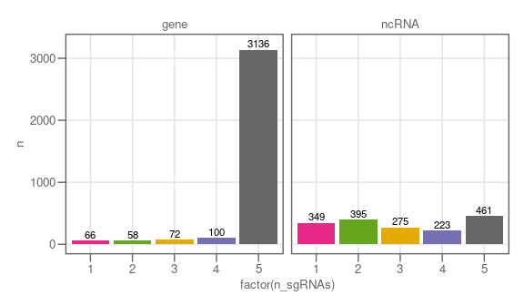

```r
# N genes with 1,2,3,4 or 5 sgRNAs
plot_sgRNAs_per_gene <- df_main %>%
  group_by(sgRNA_type, sgRNA_target) %>%
  summarize(n_sgRNAs = length(unique(sgRNA_position)), .groups = "drop_last") %>%
  count(n_sgRNAs) %>% filter(n_sgRNAs <= 5) %>%
  ggplot(aes(x = factor(n_sgRNAs), y = n, fill = factor(n_sgRNAs),
    label = n)) +
  geom_col(show.legend = FALSE) +
  geom_text(size = 3, nudge_y = 100) +
  facet_grid(~sgRNA_type) +
  custom_theme() +
  scale_fill_manual(values = custom_colors)

print(plot_sgRNAs_per_gene)
```

```r
save_plot(plot_sgRNAs_per_gene, width = 6, height = 3.5)
```

# 3 Normalization

## 3.1 Fitness distribution of all conditions

Before biological analysis continues, we need to check if fitness (and log2 FC from which it is calculated) is equally distributed. For example, strictly essential genes like ribosomal genes should show the same degreee of depletion over time, regardless of condition.

We can compare fitness over all conditions using a scatter plot matrix. We can see that some conditions are very similar to each other, for example the conditions treated with glucose (`LC, LL +g`, `LC, LL, +D, +G`, `HC, LL +g`). Others are more dissimilar to the rest, for example `LC, IL` and `LC, LL, +FL`. They are more alike each other, although `LC, LL, +FL` should be more comparable to `LC, LL`, hinting at experimental bias. In this case both of these conditions (and `LC, LL, +G`) were pre-cultivated in low light instead of high light, as opposed to the rest of the samples.

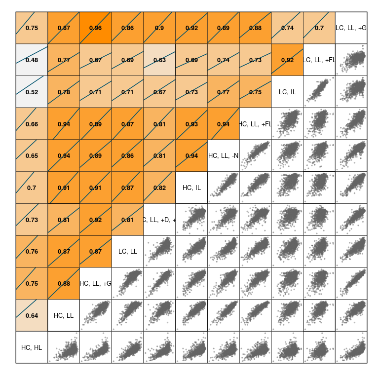

```r
df_main %>% filter(time == 0, sgRNA_index == 1) %>%
  select(locus, condition, fitness) %>%
  filter(!is.na(locus)) %>%
  pivot_wider(names_from = condition, values_from = fitness) %>%
  select(-locus) %>%
  custom_splom(pch = 19, cex = 0.3, col = grey(0.4, 0.4), pscales = 0)
```

## 3.2 Normalization strategy

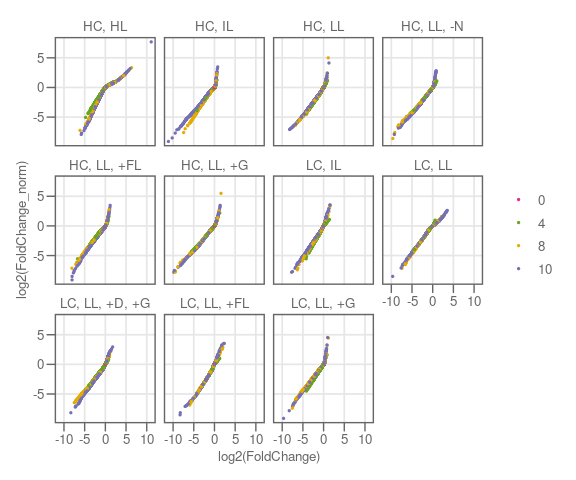

```r
# construct a normalization function that takes three colums as input,
# the numeric variable to be normalized, the conditioning variable
# (character or factor), and an ID that identifies each observation (sgRNA)
apply_norm = function(id, cond, var) {
  df_orig <- tibble(id = id, cond = cond, var = var)
  df_new <- pivot_wider(df_orig, names_from = cond, values_from = var) %>%
  column_to_rownames("id") %>% as.matrix %>%
  limma::normalizeBetweenArrays(method = "quantile") %>%
  as_tibble(rownames = "id") %>%
  pivot_longer(-id, names_to = "cond", values_to = "var_norm")
  left_join(df_orig, df_new, by = c("id", "cond")) %>% pull(var_norm)
}

# apply normalization
df_main <- df_main %>%
  mutate(FoldChange = 2^log2FoldChange) %>%
  group_by(time) %>%
  mutate(
    FoldChange_norm = apply_norm(sgRNA, condition, FoldChange),
    log2FoldChange = log2(FoldChange_norm)
  ) %>% ungroup

# compare effect of normalization
df_main %>% group_by(condition) %>% slice(1:10000) %>%
  ggplot(aes(x = log2(FoldChange), y = log2(FoldChange_norm), color = factor(time))) +
  geom_point(size = 0.5) +
  facet_wrap(~ condition, ncol = 4) +
  custom_theme() +
  scale_color_manual(values = custom_colors)
```

Another way to look at the result of the normalization is to compare the global distribution of log2 FC values, as a density plot.

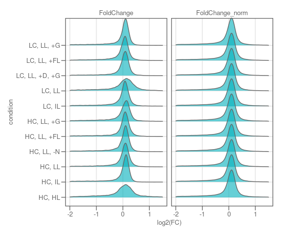

```r
library(ggridges)
df_main %>% filter(time == 10) %>%
  select(sgRNA, condition, FoldChange, FoldChange_norm) %>%
  pivot_longer(matches("^Fold"), names_to = "metric", values_to = "FC") %>%
  distinct %>%
  ggplot(aes(x = log2(FC), y = condition, group = condition)) +
  geom_density_ridges(fill = "#00AFBB99", col = grey(0.4)) +
  facet_wrap(~ metric, ncol = 4) +
  lims(x = c(-2, 1.5)) +
  custom_theme()
```

Now we need to re-calculate fitness based on the normalized log2 FC.

```r
df_main <- df_main %>%
  select(-FoldChange, -FoldChange_norm) %>%
  group_by(sgRNA, condition) %>%
  mutate(fitness = DescTools::AUC(time, log2FoldChange)/(max(time)/2)) %>%
  arrange(sgRNA_target, sgRNA_index, condition, time)
```

# 4 Fitness score aggregation

## 4.1 Correlation of sgRNAs

Different methods can be used to estimate similarity between samples (sgRNAs). For example, factor analysis is a method to dissect underlying sources of variation within the dataset, and the contribution to overall variation. The most famous example is principal component analysis (PCA). We can also use the correlation coefficient of sgRNAs to each other to see if one of the sgRNAs contributes stronger to overall variation.

This is an example of an apparently strictly essential gene, encoding the ribosomal protein `rps10`. Most of the sgRNA repressor strains are depleted, the correlation between sgRNAs is high. The strength of depletion varies though, and the strain with sgRNA 3 is not depleted at all. We want to give higher weights to sgRNAs that correlate well with each other, and/or show stronger effect (depletion/enrichment).

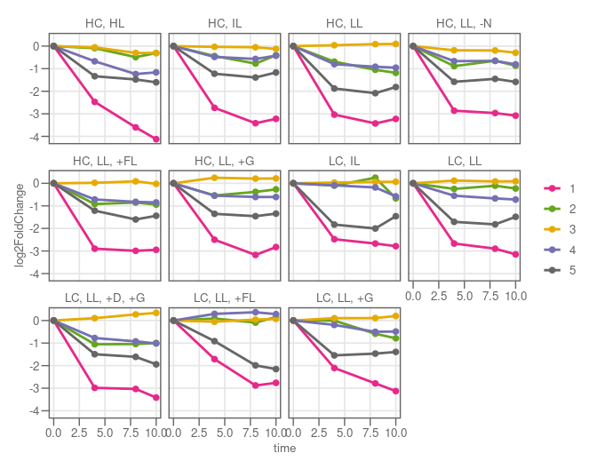

```r
plot_sgRNA_ribo_example <- df_main %>% filter(sgRNA_target == "rps10") %>%
  mutate(sgRNA_index = factor(sgRNA_index, 1:5)) %>%
  ggplot(aes(x = time, y = log2FoldChange, color = sgRNA_index)) +
  geom_line(size = 1) + geom_point(size = 2) +
  facet_wrap(~ condition, ncol = 4) +
  custom_theme() +
  scale_color_manual(values = custom_colors)

print(plot_sgRNA_ribo_example)
```

```r
save_plot(plot_sgRNA_ribo_example, width = 7, height = 5.5)
```

A correlation score can be calculated by computing the correlation coefficient of all sgRNAs to each other. This score is robustly summarized by taking the median, and rescaling it from the respective minima and maxima [-1, 1] to [0, 1]. This score serves as a weight component for each sgRNA to calculate the (global) weighted mean of log2 FC over all sgRNAs. The score has the characteristic that it gives a weight of 1 for an sgRNA perfectly correlated with all other sgRNAs of the same gene, and a weight of 0 for sgRNAs perfectly anti-correlated to the other sgRNAs.

For a matrix of $x = 1 .. m$ sgRNAs and $y = 1 .. n$ observations (measurements), the correlation $R$ of one sgRNA to another is calculated using Pearson’s method:

$R_x=cor([log_2FC_{x1,y1} ... log_2FC_{x1,yn}], [log_2FC_{x2,y1} ... log_2FC_{x2,yn}])$

The correlation weight of one sgRNA is then calculated as median of all $R$ rescaled between 0 and 1.

$w_x = \frac{1 + median(R_1, R_2, ..., R_m)}{2}$

The following example shows the correlation matrix for the 5 `rps10` sgRNAs, and their weights. The self correlation of each sgRNA (R = 1) is removed prior to weight determination.

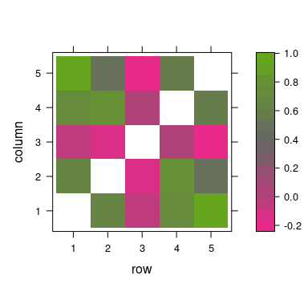

```r
cor_matrix <- df_main %>% filter(sgRNA_target == "rps10") %>% ungroup %>%
  select(sgRNA_index, log2FoldChange, condition, time) %>%
  pivot_wider(names_from = c("condition", "time"), values_from = log2FoldChange) %>%
  arrange(sgRNA_index) %>% column_to_rownames("sgRNA_index") %>%
  as.matrix %>% t %>% cor(method = "pearson")

weights <- cor_matrix %>% replace(., . == 1, NA) %>%
  apply(2, function(x) median(x, na.rm = TRUE)) %>%
  rescale(from = c(-1, 1), to = c(0, 1))

# plot heatmap
lattice::levelplot(cor_matrix %>% replace(., . == 1, NA),
  col.regions = colorRampPalette(custom_colors[c(1,5,2)])(20))
```

```r
# print weights
weights
```

```
        1         2         3         4         5
0.8440521 0.7864564 0.4605635 0.8265134 0.7689177
```

Now we can create a function that will compute weights for all sgRNAs, and add the weights to the data set.

```r
determine_corr <- function(index, value, condition, time) {
  # make correlation matrix
  df <- data.frame(index = index, value = value, condition = condition, time = time)
  cor_matrix <- pivot_wider(df, names_from = c("condition", "time"), values_from = value) %>%
    arrange(index) %>% column_to_rownames("index") %>%
    as.matrix %>% t %>% cor(method = "pearson")

  # determine weights
  weights <- cor_matrix %>% replace(., . == 1, NA) %>%
    apply(2, function(x) median(x, na.rm = TRUE)) %>%
    scales::rescale(from = c(-1, 1), to = c(0, 1)) %>%
    enframe("index", "weight") %>% mutate(index = as.numeric(index)) %>%
    mutate(weight = replace(weight, is.na(weight), 1))

  # return vector of weights the same order and length
  # as sgRNA index vector
  left_join(df, weights, by = "index") %>% pull(weight)
}

df_main <- df_main %>%
  group_by(sgRNA_target) %>%
  mutate(sgRNA_correlation = determine_corr(sgRNA_index,
    log2FoldChange, condition, time))
```

## 4.2 Efficiency of sgRNAs

The correlation of each sgRNA with each other is a “global” parameter as it is identical over all conditions. A second global parameter, **sgRNA efficiency**, can be obtained using a similar approach. We expect that fitness of all sgRNAs for one gene is not normally distributed because sgRNAs are not ideal replicate measurements. They are biased by position effects and off-target binding, see [Wang et al., Nature Comms, 2018](https://www.nature.com/articles/s41467-018-04899-x) for a very insightful and comprehensive analysis of the number and position of sgRNAs required to estimate gene fitness.

We calculate sgRNA efficiency $E$ as the median absolute fitness (AUC of log2FC over time) of an sgRNA $x = 1 .. m$ over all observations [conditions] $y = 1 .. n$.

$E_x=median(abs(fitness_{x1, y1}, fitness_{x1, y2}, ..., fitness_{x1, yn}))$

To normalize between all sgRNAs, $E$ is rescaled to a range between 0 and 1.

$E_x=\frac{E_x}{max(E_1, E_2, ..., E_m)}$

```r
df_main <- df_main %>% group_by(sgRNA_target) %>%
  mutate(sgRNA_efficiency = ave(fitness, sgRNA_index, FUN = function(x) median(abs(x))) %>%
    {./max(.)})
```

This is the resulting sgRNA efficiency for the example gene above, `rps10`.

```r
df_main %>% filter(sgRNA_target == "rps10") %>% ungroup %>%
  select(sgRNA_index, sgRNA_efficiency) %>% distinct %>%
  arrange(sgRNA_index) %>% deframe
```

```
        1         2         3         4         5
1.0000000 0.1519365 0.0351794 0.2105323 0.5110918
```

## 4.3 Position bias of sgRNA repression

Plot the **weight of each sgRNA** to see if there is a dependency between correlation and sgRNA position. There is no significant trend.

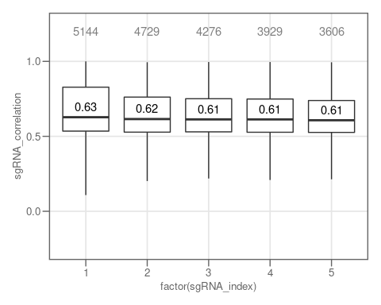

```r
plot_sgRNA_correlation <- df_main %>%
  select(sgRNA_target, sgRNA_index, sgRNA_correlation) %>%
  filter(sgRNA_index <= 5) %>%
  distinct %>%
  # plot
  ggplot(aes(x = factor(sgRNA_index), y = sgRNA_correlation)) +
  geom_boxplot(outlier.shape = "") +
  stat_summary(fun.data = function(x) c(y = median(x)+0.07,
    label = round(median(x), 2)), geom = "text") +
  stat_summary(fun.data = function(x) c(y = 1.2,
    label = length(x)), geom = "text", color = grey(0.5)) +
  coord_cartesian(ylim = c(-0.25, 1.25)) +
  custom_theme()

save_plot(plot_sgRNA_correlation, width = 5, height = 4)
print(plot_sgRNA_correlation)
```

We can also quantify how many genes have strongly correlated sgRNAs and how many have outliers. In order to do this, the median weight of the (up to) 5 sgRNAs per gene is plotted. Generally, the median weight ranges between 0.5 and 1.0, showing on average good correlation.

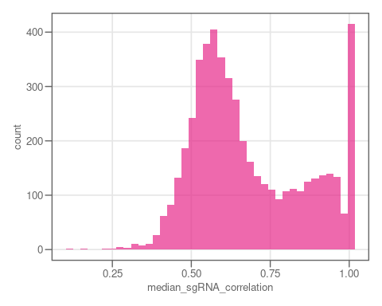

```r
plot_sgRNA_correlation_hist <- df_main %>%
  select(sgRNA_target, sgRNA_index, sgRNA_correlation) %>%
  filter(sgRNA_index <= 5) %>%
  distinct %>% group_by(sgRNA_target) %>%
  summarize(
    median_sgRNA_correlation = median(sgRNA_correlation),
    min_sgRNA_correlation = min(sgRNA_correlation)
  ) %>%
  # plot
  ggplot(aes(x = median_sgRNA_correlation)) +
  geom_histogram(bins = 40, fill = custom_colors[1], alpha = 0.7) +
  custom_theme()

save_plot(plot_sgRNA_correlation_hist, width = 5, height = 4)
print(plot_sgRNA_correlation_hist)
```

Second, the binding position of the sgRNAs could be correlated to the strength of repression. In other words sgRNAs binding closer to the promoter could have stronger ability to repress a gene, see Figure 1 B in [Wang et al., Nature Comms, 2018](https://www.nature.com/articles/s41467-018-04899-x). We plot **sgRNA efficiency** for genes only, because the absolute majority of those has 5 sgRNAs.

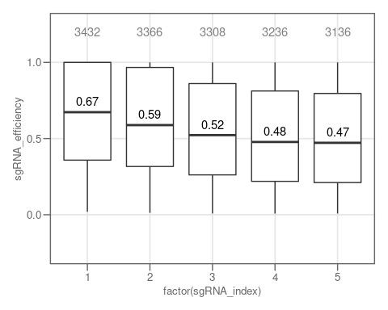

```r
plot_sgRNA_efficiency <- df_main %>%
  filter(sgRNA_index <= 5, sgRNA_type == "gene") %>%
  select(sgRNA_target, sgRNA_index, sgRNA_efficiency) %>% distinct %>%
  ggplot(aes(x = factor(sgRNA_index), y = sgRNA_efficiency)) +
  geom_boxplot(notch = FALSE, outlier.shape = ".") +
  coord_cartesian(ylim = c(-0.25, 1.25)) +
  stat_summary(fun.data = function(x) c(y = median(x)+0.07,
    label = round(median(x), 2)), geom = "text") +
  stat_summary(fun.data = function(x) c(y = 1.2,
    label = length(x)), geom = "text", color = grey(0.5)) +
  custom_theme()

save_plot(plot_sgRNA_efficiency, width = 5, height = 4)
print(plot_sgRNA_efficiency)
```

# 5 Gene fitness calculation

## 5.1 Summarize sgRNA fitness to gene fitness

With the correlation and the efficiency per sgRNA, we can compute the **weighted mean of all sgRNAs**. For comparison, we also test simple strategies such as the standard **arithmetic mean** and a top 1 and top 2 sgRNAs strategy. Metrics are calculated for log2 FC, and fitness.

```r
df_gene <- df_main %>%

  # keep all annotation columns
  group_by(sgRNA_target, sgRNA_type, locus, gene_name, condition,
    carbon, light, treatment, time) %>%

  # summarize FC and fitness...
  summarize(.groups = "drop",
    # log2 FC
    mean_log2FoldChange = mean(log2FoldChange),
    wmean_log2FoldChange = weighted.mean(log2FoldChange, sgRNA_correlation * sgRNA_efficiency),
    top1_log2FoldChange = log2FoldChange[which.max(sgRNA_efficiency)],
    top2_log2FoldChange = mean(log2FoldChange[order(sgRNA_efficiency, decreasing = TRUE)[1:2]]),
    sd_log2FoldChange = sd(log2FoldChange),
    # fitness
    mean_fitness = mean(fitness),
    wmean_fitness = weighted.mean(fitness, sgRNA_correlation * sgRNA_efficiency),
    top1_fitness = fitness[which.max(sgRNA_efficiency)],
    top2_fitness = mean(fitness[order(sgRNA_efficiency, decreasing = TRUE)[1:2]]),
    sd_fitness = sd(fitness)
  )
```

A comparison of log2 FC aggregated by the different method shows clear differences. For the example gene `rps10` the weighted mean and the top method give similar results, representative of the stronger influence from highly depleted sgRNA repression strains. The regular mean is robust, but “shallow”, probably underestimating the real effect n fitness. The top 1 method simply picks the most depleted/enriched sgRNA (over all conditions) as representative.

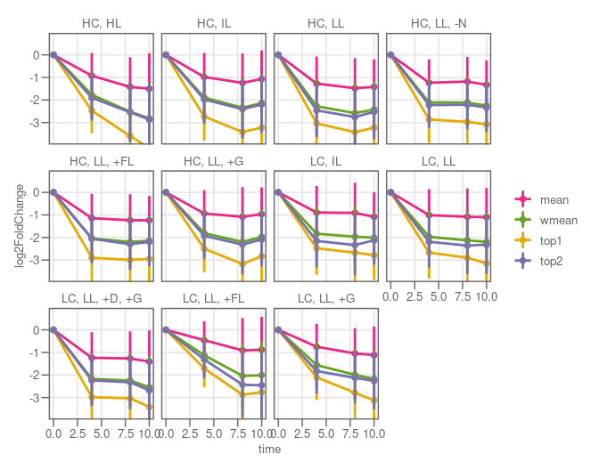

```r
df_gene %>% filter(sgRNA_target == "rps10") %>%
  pivot_longer(cols = matches("[n12]_log2FoldChange"),
    names_to = "metric", values_to = "log2FoldChange") %>%
  mutate(metric = str_remove(metric, "_log2FoldChange")) %>%
  ggplot(aes(x = time, y = log2FoldChange,
    ymin = log2FoldChange-sd_log2FoldChange,
    ymax = log2FoldChange+sd_log2FoldChange, color = fct_inorder(metric))) +
  geom_line(size = 1) + geom_point(size = 2) + geom_linerange(size = 1) +
  facet_wrap(~ condition, ncol = 4) +
  custom_theme(legend.position = "right") +
  coord_cartesian(ylim = c(-3.75, 0.75)) +
  scale_color_manual(values = custom_colors)
```

This plot shows a comparison of the 4 methods for the first 36 genes by alphabetical order, for one selected condition only (1% CO2, BG11, 1,000 µmol photons m-1 s-1). Here we can see that the top1 method is often but not always representative for the gene: For apcD or apcF, it does not seem representative compared to the mean, weighted mean, and top2 methods.

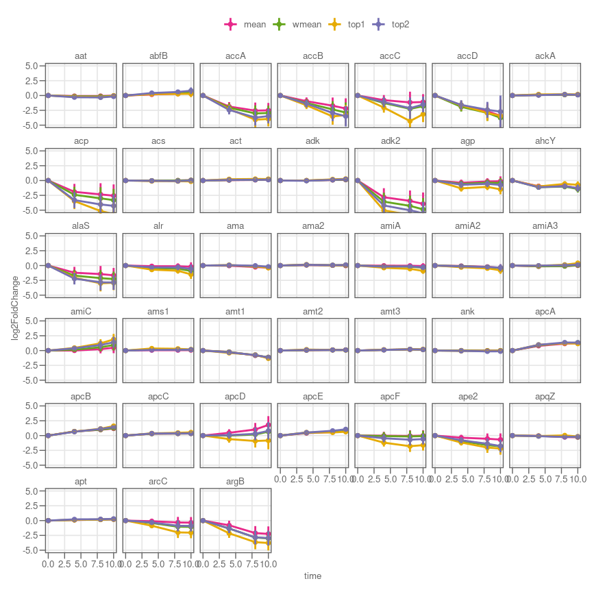

```r
df_gene %>% filter(
    gene_name %in% unique(.data[["gene_name"]])[1:36],
    condition == "HC, HL"
  ) %>%
  pivot_longer(cols = matches("[n12]_log2FoldChange"), names_to = "metric", values_to = "log2FoldChange") %>%
  mutate(metric = str_remove(metric, "_log2FoldChange")) %>%
  ggplot(aes(x = time, y = log2FoldChange,
    ymin = log2FoldChange-sd_log2FoldChange,
    ymax = log2FoldChange+sd_log2FoldChange, color = fct_inorder(metric))) +
  geom_line(size = 1) + geom_point(size = 2) + geom_linerange(size = 1) +
  facet_wrap(~ sgRNA_target, ncol = 7) +
  custom_theme(legend.position = "top") +
  coord_cartesian(ylim = c(-5, 5)) +
  scale_color_manual(values = custom_colors)
```

## 5.2 Global distribution of gene fitness

Global distribution of weighted mean fitness for all genes. Effect of ncRNA repression seems to be much lower than effect of gene repression.

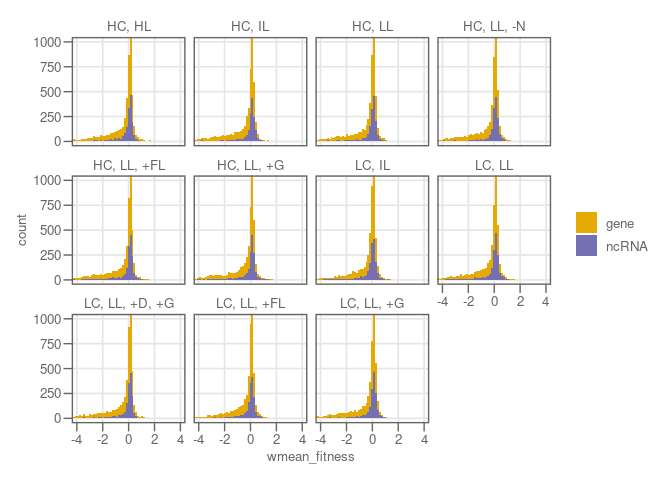

```r
plot_all_fitness_hist <- df_gene %>% filter(time == 0) %>%
  ggplot(aes(x = wmean_fitness, fill = sgRNA_type)) +
  geom_histogram(bins = 100) +
  coord_cartesian(xlim = c(-4, 4), ylim = c(0, 1000)) +
  facet_wrap( ~ condition, ncol = 4) +
  custom_theme() +
  scale_fill_manual(values = custom_colors[3:4])

print(plot_all_fitness_hist)
```

```r
save_plot(plot_all_fitness_hist, width = 7, height = 5)
```

## 5.3 Behavior of control sgRNAs

Ten sgRNAs were included in the library that have no gene-specific targets. The following plot shows that these negative controls do not have an effect on strain fitness, except probably 2 sgRNAs in one specific condition.

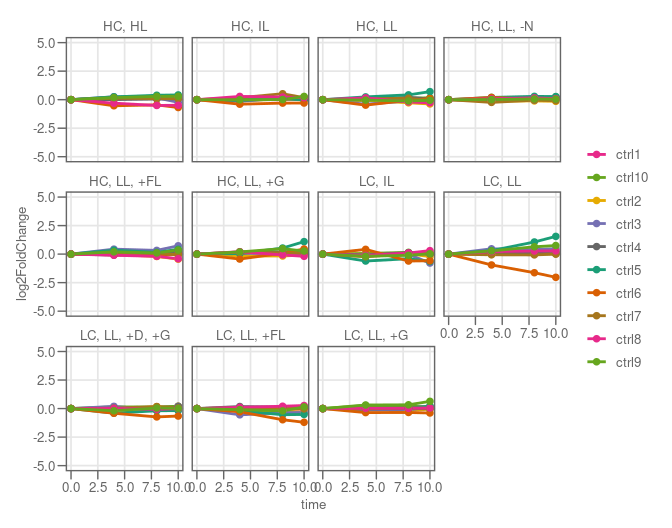

```r
plot_controls_sgRNAs <- df_main %>% filter(grepl("ctrl", sgRNA_target)) %>%
  ggplot(aes(x = time, y = log2FoldChange, color = sgRNA_target)) +
  geom_line(size = 1) + geom_point(size = 2) + ylim(-5, 5) +
  facet_wrap(~ condition, ncol = 4) +
  custom_theme() +
  scale_color_manual(values = rep_along(1:10, custom_colors))

print(plot_controls_sgRNAs)
```

```r
save_plot(plot_controls_sgRNAs, width = 7, height = 5.5)
```

# 6 Unsupervised clustering of genes

## 6.1 Cluster genes by similarity

```r
# generate color palette for heatmap
heat_cols <- colorspace::diverging_hcl(n = 7, h = c(255, 12), c = c(50, 80), l = c(20, 97), power = c(1, 1.3))

# create a matrix-like df with wide fitness data for plotting heatmap
df_heatmap <- df_gene %>%
  filter(time == 0, !is.na(locus)) %>%
  select(locus, condition, wmean_fitness) %>%
  mutate(wmean_fitness = wmean_fitness %>% replace(., . > 8, 8) %>% replace(., . < -8, -8)) %>%
  pivot_wider(names_from = condition, values_from = wmean_fitness) %>%
  column_to_rownames(var = "locus")

# subset of df with *strongly changed* genes
df_heatmap2 <- df_heatmap %>%
  filter(if_any(.cols = matches("[HL]C, "), ~ !between(., -4, 4)))

# create cluster for reordering
mat_cluster <- df_heatmap %>% as.matrix %>% dist %>% hclust(method = "ward.D2")
mat_heatmap <- df_heatmap %>% as.matrix %>%
  .[order.dendrogram(as.dendrogram(mat_cluster)), ncol(.):1]

# repeat this step with subset of *significantly changed* genes
mat_cluster_sig <- df_heatmap2 %>% as.matrix %>% dist %>% hclust(method = "ward.D2")
mat_heatmap_sig <- df_heatmap2 %>% as.matrix %>%
  .[order.dendrogram(as.dendrogram(mat_cluster_sig)), ncol(.):1]
```

Now we can plot *all* genes, a subset with *only significant genes*, and a dendrogram for clustering. The result is hard to interpret. With some exceptions, most genes are grouped in broad unspecific clusters that do not reveal clear relationships between treatment variables and fitness outcome.

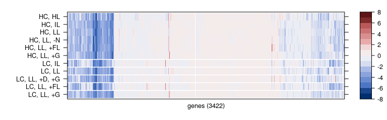

```r
plot_heatmap_all <- levelplot(mat_heatmap,
  par.settings = custom.colorblind(),
  col.regions = colorRampPalette(heat_cols)(20),
  at = seq(-8, 8, 1), aspect = "fill",
  xlab = paste0("genes (", nrow(mat_heatmap),")"),
  ylab = "", scales = list(x = list(draw = FALSE)),
  panel = function(x, y, z, ...) {
    panel.levelplot(x, y, z, ...)
    panel.abline(h = 1:5+0.5, col = "white", lwd = 1.5)
  }
)

print(plot_heatmap_all)
```

```r
save_plot(plot_heatmap_all, width = 8, height = 2.5)
```

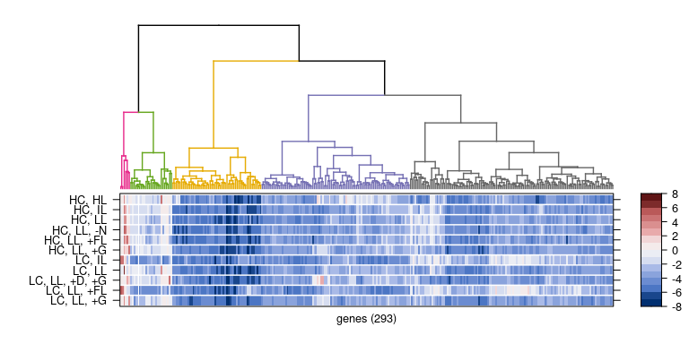

```r
plot_heatmap_sig <- levelplot(mat_heatmap_sig,
  par.settings = custom.colorblind(),
  col.regions = colorRampPalette(heat_cols)(20),
  at = seq(-8, 8, 1), aspect = "fill",
  xlab = paste0("genes (", nrow(mat_heatmap_sig),")"),
  ylab = "", scales = list(x = list(draw = FALSE)),
  panel = function(x, y, z, ...) {
    panel.levelplot(x, y, z, ...)
    panel.abline(h = 1:ncol(mat_heatmap_sig)+0.5, col = "white", lwd = 1.5)
  }
)

plot_cluster_dend <- mat_cluster_sig %>% as.dendrogram %>%
  set("branches_k_col", custom_colors[1:5], k = 5) %>%
  set("branches_lwd", 0.5) %>%
  as.ggdend %>%
  ggplot(labels = FALSE)
gridExtra::grid.arrange(
  # coords for unit: top, right, bottom, left
  plot_cluster_dend +
    theme(plot.margin = unit(c(0.1, 0.075, -0.26, 0.135),"npc")),
  plot_heatmap_sig,
  nrow = 2
)
```

## 6.2 Gene similarity by dimensionality reduction methods

We use two different dimensionality reduction methods, **nMDS** and **t-SNE**. We can check if these methods reproduce the clustering for the significantly regulated genes produced with `hclust`. Analysis shows that the small clusters are more strongly separated from the rest.

```r
# set a seed to obtain same pattern for stochastic methods
set.seed(123)

# run nMDS analysis
NMDS <- df_heatmap2 %>% as.matrix %>% dist %>% metaMDS
```

```
*** Solution reached
```

```r
df_nmds <- NMDS$points %>% as_tibble(rownames = "locus") %>%
  left_join(enframe(cutreeord(mat_cluster_sig, k = 5), "locus", "cluster"))
# run t-SNE analysis
SNE <- tsne::tsne(df_heatmap2 %>% as.matrix %>% dist)
```

```
sigma summary: Min. : 0.51453154858122 |1st Qu. : 0.646910330520664 |Median : 0.714309515627356 |Mean : 0.746309912193634 |3rd Qu. : 0.79479345979067 |Max. : 1.58041817397143 |
Epoch: Iteration #100 error is: 14.170258824269
Epoch: Iteration #200 error is: 0.423942816192504
Epoch: Iteration #300 error is: 0.406398188540306
Epoch: Iteration #400 error is: 0.404698129239104
Epoch: Iteration #500 error is: 0.404337884848916
Epoch: Iteration #600 error is: 0.404205045213674
Epoch: Iteration #700 error is: 0.404146174344848
Epoch: Iteration #800 error is: 0.404117696326219
Epoch: Iteration #900 error is: 0.404102464318572
Epoch: Iteration #1000 error is: 0.404093843400558
```

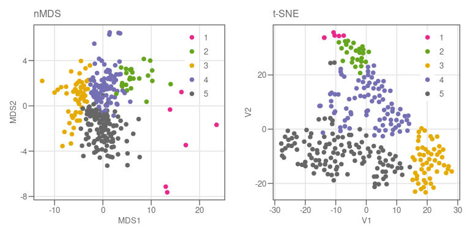

```r
df_tsne <- SNE %>% setNames(c("x", "y")) %>% as_tibble %>%
  mutate(locus = rownames(df_heatmap2)) %>%
  left_join(enframe(cutreeord(mat_cluster_sig, k = 5), "locus", "cluster"))
plot_nmds <- df_nmds %>%
  ggplot(aes(x = MDS1, y = MDS2, color = factor(cluster))) +
  geom_point(size = 2) + labs(title = "nMDS") +
  custom_theme(legend.position = c(0.85, 0.78)) +
  scale_color_manual(values = custom_colors)

plot_tsne <- df_tsne %>%
  ggplot(aes(x = V1, y = V2, color = factor(cluster))) +
  geom_point(size = 2) + labs(title = "t-SNE") +
  custom_theme(legend.position = c(0.85, 0.78)) +
  scale_color_manual(values = custom_colors)

gridExtra::grid.arrange(plot_nmds, plot_tsne, ncol = 2)
```

```r
ggsave("../figures/plot_nmds_tsne.svg", plot = gridExtra::arrangeGrob(plot_nmds, plot_tsne, ncol = 2),
  device = "svg", width = 8, height = 4)
```

## 6.3 Fit multiple linear regression models

We can find clusters of genes with similar fitness, but it is also important to identify *why* they cluster together. In order to find out *which variables* determine the fitness outcome of a gene, we can perform **multiple linear regression**. Each gene needs to have fitness outcomes annotated with the different (mixed) variables `carbon`, `light`, `treatment`. The latter can be subdivided in individual treatment columns glucose, DCMU, fluctuating light, and so on. Multiple linear regression fits a linear model of the following form to the data:

`response ~ intercept + predictor A x slope A + predictor B x slope B x ...`

Here, `fitness` is the response variable, the different conditions are the predictors. It is important to convert the categorical predictors into (numerical) dummy variables. Then for each individual gene, multiple linear models are fitted and the power of each predictor variable to predict the response is extracted.

```r
# fixed model with 6 predictor variables -- dynamic layout would
# be better in future
fit_linreg <- function(y, x1, x2, x3, x4, x5, x6){
  fit <- lm(y ~ x1 + x2 + x3 + x4 + x5 + x6)
  c(coefficients(fit), summary(fit)$coefficients[, 4],
    summary(fit)$r.squared)
}

# recode categorical to numerical (dummy) variables
df_linreg <- df_gene %>%
  filter(!is.na(locus)) %>%
  select(locus, carbon, light, treatment, wmean_fitness) %>% distinct %>%
  mutate(
    carbon = recode(carbon, `HC` = 1, `LC` = 0),
    light = recode(light, `LL` = 0, `IL` = 0.5, `HL` = 1)) %>%
  mutate(dummy = 1, treatment = replace(treatment, treatment == "", "-")) %>%
  pivot_wider(names_from = treatment, values_from = dummy, values_fill = 0) %>%
  mutate(`+G` = `+G` + `+D, +G`) %>% rename(`+D` = `+D, +G`) %>% select(-`-`) %>%
  # fit model
  group_by(locus) %>%
  summarize(coefficient = fit_linreg(wmean_fitness, carbon, light, `-N`, `+FL`, `+G`, `+D`),
    .groups = "keep") %>% #unnest(coefficient) %>%
  mutate(treatment = c(rep(c("intercept", "carbon", "light", "-N", "+FL", "+G", "+D"), 2) %>%
    paste0(rep(c("", "pval_"), each = 7), .), "r_squared"))
```

Now we can overlay the information of the best predictor variable on the cluster map produced by tSNE, for example, and this way identify groups of genes regulated in a similar degree, by similar variables.

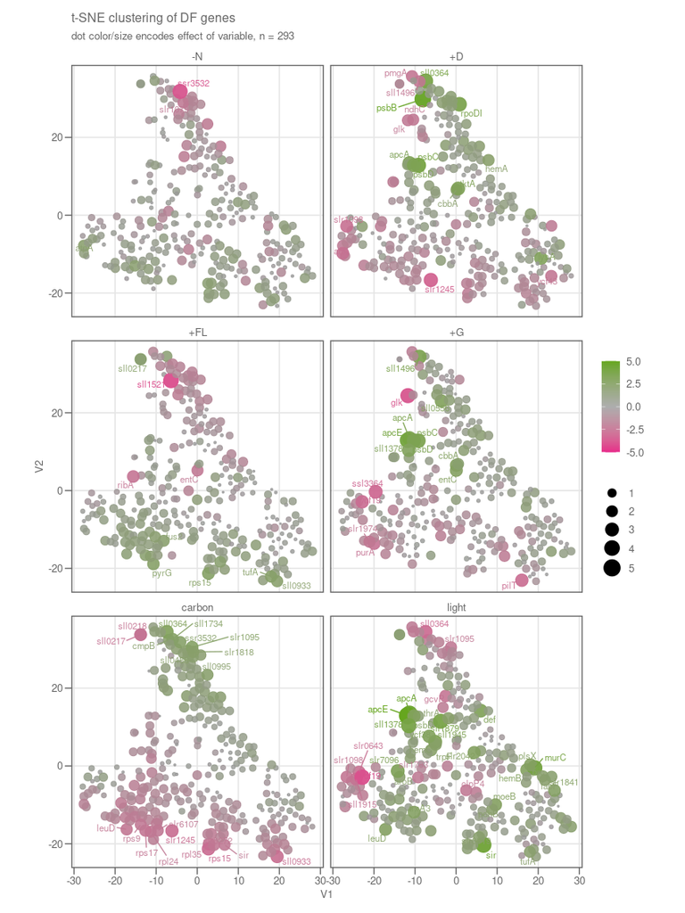

```r
plot_tsne_linreg <- df_tsne %>%
  inner_join(df_linreg, by = "locus") %>%
  left_join(select(df_gene, locus, sgRNA_target) %>% distinct, by = "locus") %>%
  filter(!str_detect(treatment, "intercept|pval|r_squared")) %>%
  mutate(sgRNA_target = if_else(abs(coefficient) > 2, sgRNA_target, "")) %>%
  mutate(point_size = abs(coefficient),
    coefficient = coefficient %>% replace(., . > 5, 5) %>% replace(., . < -5, -5)) %>%

  ggplot(aes(x = V1, y = V2, size = point_size,
    color = coefficient, label = sgRNA_target)) +
  geom_point() +
  labs(title = "t-SNE clustering of DF genes",
    subtitle = paste0("dot color/size encodes effect of variable, n = ", nrow(df_tsne))) +
  custom_theme(aspect = 1) +
  scale_color_gradientn(limits = c(-5, 5),
    colours = c(custom_colors[1], grey(0.6, 0.8), custom_colors[2])) +
  scale_size_continuous(range = c(0.5, 7)) +
  geom_text_repel(size = 3, max.overlaps = 50) +
  facet_wrap( ~ treatment, ncol = 2)

print(plot_tsne_linreg)
```

This strategy reveals a list of interesting condition-specific genes:

- Nitrogen limitation: `ssr3532` - unknown short protein, strongest known interaction in STRING with GlsA glutaminase
- Fluctuating light:
  - `sll1521` - Putative diflavin flavoprotein A3 (dfa3), negatively corr. with fitness
  - `sll0217` Putative diflavin flavoprotein A2 (dfa2), positively corr. with fitness
- Mixotrophy:
  - `sll0593` - glk, glucokinase, catalyzes P-ylation of Glc to G6P
  - `sll1533` - pilT, fimbria assembly, mobility, Glc transport or sensing?
  - `ssl3364` - unknown short protein, strongly interacts with RbcX, RbcR, Prk. Important for C-metabolism adapation?
- Light:
  - `ssr2142` ycf19, short unknown protein, interacts with psbO and Tat membrane protein insertion system,
  - `slr0963` sir, sulfite reductase, ferredoxin H2O + HS + ferredoxin <-> H+ + reduced ferredoxin + sulfite, strongly interacts with other proteins in sulfur metabolism, specifically related to cofactor biosynthesis, cobalamin (vitamin B12) and siroheme
- Light, mixotrophy, heterotrophy: cluster of photosynthesis related genes increase fitness when KOed: apcA,D,E, psbB,C,D
- Carbon:
  - `sll0217` Putative diflavin flavoprotein A2 (dfa2), KO negatively correlated with fitness with C, positive with +FL
  - `sll0218` same behavior as dfa2, interacts with dfa2,4, contributes to PSII stabilization, [Bersanini et al., 2017](https://pubmed.ncbi.nlm.nih.gov/27928824/)

## 6.4 List of genes with strong fitness correlation

The table with linear regression coefficients and p-values is reshaped to long format for better readability. The `kableExtra` package is used to color cells for easier recognition. Then we subset the table for each treatment in order to spot the most interesting genes.

```r
library(kableExtra)

df_linreg_wide <- df_linreg %>%
  pivot_wider(names_from = treatment, values_from = coefficient) %>%
  left_join(select(df_gene, locus, sgRNA_target) %>% distinct, by = "locus") %>%
  select(-matches("intercept")) %>%
  filter(if_any(matches("^(carb|light|\\-|\\+)"), ~ abs(.) > 2)) %>%
  mutate(across(matches("carb|light|\\-|\\+"), ~ round(., 3))) %>%
  ungroup %>% select(sgRNA_target, locus, matches("."))

color_table <- function(df, variable) {
  filter(df, abs(.data[[variable]]) > 2) %>%
  select(matches("^(sg|loc|r_s|carb|light|\\-|\\+)") | all_of(paste0("pval_", variable))) %>%
  arrange(desc(.data[[variable]])) %>%
  mutate(across(3:8, ~ cell_spec(., "html", color = "white",
      background = spec_color(., option = "E", scale = c(-5.5, 5.5)),
      bold = TRUE))) %>%
  kbl(format = "html", escape = F) %>%
  kable_paper("striped", full_width = F)
}
```

```r
df_linreg_wide %>% color_table("carbon")
```

| sgRNA_target | locus | carbon | light | -N | +FL | +G | +D | r_squared | pval_carbon |
| --- | --- | --- | --- | --- | --- | --- | --- | --- | --- |
| sll0364 | sll0364 | 2.834 | -2.812 | -0.108 | 1.758 | 0.601 | 3.578 | 0.8717770 | 0.024 |
| slr1095 | slr1095 | 2.429 | -2.1 | -1.284 | -1.592 | -0.274 | 1.777 | 0.6370579 | 0.083 |
| sll1734 | sll1734 | 2.426 | -1.267 | -0.478 | -1.625 | 0.837 | 1.183 | 0.6560893 | 0.099 |
| slr0211 | slr0211 | 2.354 | 0.469 | -0.044 | -0.362 | 0.786 | 1.884 | 0.8217569 | 0.022 |
| ftsZ | sll1633 | 2.34 | -2.314 | -1.677 | -1.439 | 0.318 | 2.136 | 0.9249829 | 0.006 |
| ndhD3 | sll1733 | 2.326 | -1.213 | -0.489 | -1.392 | 0.67 | 1.172 | 0.6640536 | 0.085 |
| ssr3532 | ssr3532 | 2.303 | -1.661 | -3.733 | -1.464 | 0.702 | 1.64 | 0.6071408 | 0.163 |
| ndhF2 | sll1732 | 2.163 | -0.874 | -0.602 | -1.431 | 1.022 | 1.124 | 0.6649520 | 0.103 |
| slr1818 | slr1818 | 2.159 | -1.144 | -1.369 | -1.55 | -0.087 | 1.675 | 0.5831706 | 0.116 |
| sll0488 | sll0488 | 2.151 | -1.322 | -1.418 | -1.434 | 0.047 | 1.624 | 0.6312515 | 0.090 |
| sll0481 | sll0481 | 2.141 | -3.371 | -1.601 | -1.335 | 0.485 | 1.056 | 0.9686290 | 0.002 |
| sll0995 | sll0995 | 2.101 | -0.278 | -1.933 | -1.322 | 0.722 | 1.384 | 0.6077491 | 0.132 |
| cmpB | slr0041 | 2.041 | -1.904 | -0.766 | -1.032 | 0.133 | 1.15 | 0.5577051 | 0.126 |
| sir | slr0963 | -2.034 | 4.169 | 1.41 | 1.489 | -0.345 | -0.303 | 0.8364473 | 0.048 |
| rpl24 | sll1807 | -2.081 | 0.994 | 0.573 | 1.814 | 0.023 | -1.225 | 0.4871941 | 0.200 |
| rps9 | sll1822 | -2.087 | 0.874 | 0.64 | 1.319 | -0.719 | -0.988 | 0.5755515 | 0.137 |
| slr6107 | slr6107 | -2.108 | 1.215 | 1.13 | 1.151 | -0.237 | -1.246 | 0.5493324 | 0.124 |
| slr0272 | slr0272 | -2.122 | 1.596 | 1.27 | 1.27 | -1.038 | -0.791 | 0.6159525 | 0.127 |
| leuD | sll1444 | -2.209 | 2.505 | -0.124 | 1.64 | -1.451 | -0.038 | 0.6714334 | 0.146 |
| rps17 | ssl3437 | -2.241 | 0.79 | 1.027 | 1.922 | -0.148 | -1.382 | 0.5117852 | 0.184 |
| slr0007 | slr0007 | -2.308 | 1.932 | 0.695 | 2.012 | -0.851 | -1.068 | 0.6792795 | 0.109 |
| slr1938 | slr1938 | -2.311 | 0.268 | 0.592 | 1.075 | -0.772 | -1.967 | 0.7489109 | 0.051 |
| rpl35 | ssl1426 | -2.361 | 1.851 | 1.677 | 1.293 | -0.482 | -1.844 | 0.5899106 | 0.124 |
| sll0218 | sll0218 | -2.376 | 1.766 | 0.727 | 1.766 | -0.193 | -1.1 | 0.6105884 | 0.110 |
| sll0217 | sll0217 | -2.418 | 1.723 | 0.954 | 2.228 | -0.286 | -1.152 | 0.6281035 | 0.118 |
| sll0933 | sll0933 | -2.634 | 1.271 | 0.081 | 2.115 | -0.633 | -0.702 | 0.6558952 | 0.105 |
| slr1245 | slr1245 | -2.694 | 1.826 | 1.245 | -0.805 | 1.092 | -3.224 | 0.8325233 | 0.019 |
| rps15 | ssl1784 | -2.769 | 1.647 | 1.312 | 2.437 | -0.758 | -1.499 | 0.7223751 | 0.075 |

```r
df_linreg_wide %>% color_table("light")
```

| sgRNA_target | locus | carbon | light | -N | +FL | +G | +D | r_squared | pval_light |
| --- | --- | --- | --- | --- | --- | --- | --- | --- | --- |
| apcE | slr0335 | -0.681 | 5.071 | 0.314 | 1.093 | 3.962 | 1.65 | 0.8255851 | 0.055 |
| apcA | slr2067 | 0.027 | 4.441 | 0.576 | 0.809 | 3.301 | 2.922 | 0.7380667 | 0.127 |
| sll1878 | sll1878 | -1.585 | 4.291 | 2.016 | 2.165 | 1.301 | -0.213 | 0.7988744 | 0.024 |
| sir | slr0963 | -2.034 | 4.169 | 1.41 | 1.489 | -0.345 | -0.303 | 0.8364473 | 0.031 |
| cpcB | sll1577 | 0.12 | 4.032 | 0.141 | 0.74 | 2.544 | 2.476 | 0.8276584 | 0.053 |
| murC | slr1423 | 0.232 | 3.875 | 0.345 | 0.027 | 1.164 | -0.248 | 0.6419118 | 0.096 |
| sll1378 | sll1378 | -0.955 | 3.701 | -0.4 | 1.2 | 2.782 | 0.937 | 0.9545533 | 0.006 |
| sll1879 | sll1879 | -0.306 | 3.662 | -0.894 | -0.217 | 0.681 | -0.74 | 0.7312512 | 0.074 |
| hitB | slr0327 | -1.726 | 3.606 | 1.56 | 1.726 | 0.576 | -0.39 | 0.6687398 | 0.087 |
| cpcA | sll1578 | 0.11 | 3.57 | 0.261 | 0.609 | 2.255 | 2.162 | 0.8434275 | 0.044 |
| slr0947 | slr0947 | 0.18 | 3.422 | 0.454 | 0.742 | 1.52 | 0.613 | 0.7928550 | 0.028 |
| slr1990 | slr1990 | -0.768 | 3.219 | 0.197 | 0.994 | 2.472 | 2.429 | 0.8920252 | 0.044 |
| slr1102 | slr1102 | 0.056 | 3.162 | -0.118 | 0.511 | 2.737 | 0.819 | 0.8207709 | 0.065 |
| amiC | slr0447 | -1.235 | 3.159 | 0.549 | -0.175 | 1.309 | 0.402 | 0.9300166 | 0.007 |
| sll6055 | sll6055 | -1.122 | 3.123 | 0.558 | 0.514 | 2.406 | 2.128 | 0.8376624 | 0.091 |
| cyp2 | slr0574 | -0.6 | 3.073 | 0.867 | 1.027 | 2.347 | -0.438 | 0.9444943 | 0.003 |
| sll1945 | sll1945 | -0.194 | 3.072 | 0.642 | 0.625 | 0.063 | 1.299 | 0.7068087 | 0.059 |
| sll0689 | sll0689 | -0.125 | 3.062 | 0.19 | 0.41 | 0.027 | 0.162 | 0.5002592 | 0.178 |
| narB | sll1454 | -0.223 | 3.011 | 0.044 | 0.014 | 0.034 | 0.634 | 0.8309629 | 0.025 |
| def | slr1549 | 0.929 | 2.973 | 1.091 | -0.039 | 1.821 | 0.97 | 0.7394573 | 0.103 |
| slr7096 | slr7096 | -0.452 | 2.972 | -0.83 | 0.696 | -0.16 | 0.433 | 0.9130593 | 0.010 |
| psbJ | smr0008 | 0.192 | 2.968 | 0.293 | 0.419 | 3.216 | 3.222 | 0.8923081 | 0.090 |
| slr1505 | slr1505 | -0.682 | 2.926 | 0.456 | 0.864 | 2.222 | 3.068 | 0.9263147 | 0.032 |
| slr0483 | slr0483 | 0.315 | 2.922 | 0.533 | 0.633 | 1.047 | 0.53 | 0.9363725 | 0.003 |
| nirA | slr0898 | -1.083 | 2.919 | -0.106 | 0.515 | -0.343 | -0.004 | 0.7628800 | 0.063 |
| apcB | slr1986 | 0.627 | 2.876 | 0.319 | 0.432 | 2.241 | 2.188 | 0.7619664 | 0.129 |
| slr0734 | slr0734 | 0.52 | 2.819 | 0.607 | 0.753 | 1.99 | 2.183 | 0.8211958 | 0.067 |
| slr1170 | slr1170 | -0.807 | 2.766 | -0.676 | 0.308 | 0.668 | -0.598 | 0.7363329 | 0.070 |
| ycf38 | sll0760 | -0.445 | 2.748 | -0.294 | 0.164 | 0.823 | 1.469 | 0.6739376 | 0.122 |
| ssl0331 | ssl0331 | -1.177 | 2.738 | 1.195 | 1.389 | 0.463 | -1.187 | 0.8598838 | 0.019 |

[output cut: 74 more lines]

```r
df_linreg_wide %>% color_table("-N")
```

| sgRNA_target | locus | carbon | light | -N | +FL | +G | +D | r_squared | pval_-N |
| --- | --- | --- | --- | --- | --- | --- | --- | --- | --- |
| atpA | sll1326 | -0.989 | -0.069 | 2.047 | 0.064 | 0.272 | -1.903 | 0.3425321 | 0.396 |
| sll1878 | sll1878 | -1.585 | 4.291 | 2.016 | 2.165 | 1.301 | -0.213 | 0.7988744 | 0.179 |
| sll0176 | sll0176 | -0.408 | -2.085 | -2.021 | -1.717 | -1.526 | 0.952 | 0.6551709 | 0.168 |
| slr1079 | slr1079 | 1.742 | -1.553 | -2.022 | -1.193 | -0.394 | 1.843 | 0.5565884 | 0.304 |
| sll5046 | sll5046 | 1.34 | -1.273 | -2.118 | -0.985 | -0.329 | 1.365 | 0.6360797 | 0.152 |
| ssr3532 | ssr3532 | 2.303 | -1.661 | -3.733 | -1.464 | 0.702 | 1.64 | 0.6071408 | 0.201 |

```r
df_linreg_wide %>% color_table("+FL")
```

| sgRNA_target | locus | carbon | light | -N | +FL | +G | +D | r_squared | pval_+FL |
| --- | --- | --- | --- | --- | --- | --- | --- | --- | --- |
| rps15 | ssl1784 | -2.769 | 1.647 | 1.312 | 2.437 | -0.758 | -1.499 | 0.7223751 | 0.204 |
| pyrG | sll1443 | -1.738 | 0.567 | -0.111 | 2.307 | -1.107 | -0.398 | 0.6651024 | 0.212 |
| sll0217 | sll0217 | -2.418 | 1.723 | 0.954 | 2.228 | -0.286 | -1.152 | 0.6281035 | 0.258 |
| tufA | sll1099 | -1.461 | 2.041 | 1.399 | 2.218 | 0.036 | -1.078 | 0.7057584 | 0.112 |
| sll1878 | sll1878 | -1.585 | 4.291 | 2.016 | 2.165 | 1.301 | -0.213 | 0.7988744 | 0.085 |
| sll0933 | sll0933 | -2.634 | 1.271 | 0.081 | 2.115 | -0.633 | -0.702 | 0.6558952 | 0.294 |
| fus2 | sll1098 | -1.02 | 1.482 | 0.038 | 2.077 | 0.13 | -0.815 | 0.7239763 | 0.087 |
| slr0007 | slr0007 | -2.308 | 1.932 | 0.695 | 2.012 | -0.851 | -1.068 | 0.6792795 | 0.267 |
| ribC | sll0300 | -1.073 | -0.365 | -0.267 | -2.057 | -0.721 | -0.724 | 0.7973653 | 0.037 |
| entC | slr0817 | -0.511 | -0.844 | -0.456 | -2.123 | 2.558 | 0.74 | 0.9773035 | 0.009 |
| ribA | sll1894 | -0.927 | -0.39 | -0.139 | -2.37 | -0.725 | -0.64 | 0.6200967 | 0.101 |
| sll1521 | sll1521 | -0.353 | -0.754 | -0.52 | -3.993 | -0.671 | -0.342 | 0.9636366 | 0.001 |

```r
df_linreg_wide %>% color_table("+G")
```

| sgRNA_target | locus | carbon | light | -N | +FL | +G | +D | r_squared | pval_+G |
| --- | --- | --- | --- | --- | --- | --- | --- | --- | --- |
| apcE | slr0335 | -0.681 | 5.071 | 0.314 | 1.093 | 3.962 | 1.65 | 0.8255851 | 0.056 |
| dgt | sll0398 | -0.463 | 0.606 | 0.269 | 1.052 | 3.782 | -0.261 | 0.9841219 | 0.000 |
| psbO | sll0427 | 0.64 | 2.707 | 0.222 | 0.633 | 3.339 | 1.65 | 0.8838887 | 0.021 |
| apcA | slr2067 | 0.027 | 4.441 | 0.576 | 0.809 | 3.301 | 2.922 | 0.7380667 | 0.142 |
| psbC | sll0851 | -0.001 | 1.691 | 0.24 | 0.281 | 3.288 | 3.75 | 0.9364716 | 0.019 |
| sll1496 | sll1496 | 1.499 | -1.248 | -0.507 | -0.657 | 3.237 | -2.22 | 0.9150619 | 0.013 |
| psbD | sll0849 | -0.861 | 2.664 | 1.002 | -0.005 | 3.231 | 3.101 | 0.8557861 | 0.072 |
| psbJ | smr0008 | 0.192 | 2.968 | 0.293 | 0.419 | 3.216 | 3.222 | 0.8923081 | 0.037 |
| slr0758 | slr0758 | -0.644 | 1.944 | 0.251 | -0.176 | 2.791 | -1.499 | 0.9317621 | 0.005 |
| sll1378 | sll1378 | -0.955 | 3.701 | -0.4 | 1.2 | 2.782 | 0.937 | 0.9545533 | 0.006 |
| slr1102 | slr1102 | 0.056 | 3.162 | -0.118 | 0.511 | 2.737 | 0.819 | 0.8207709 | 0.050 |
| sll0556 | sll0556 | 1.268 | 0.982 | 0.25 | -0.377 | 2.727 | 0.121 | 0.7859377 | 0.060 |
| slr2070 | slr2070 | 0.846 | -0.597 | -0.408 | -0.608 | 2.711 | -1.752 | 0.7416662 | 0.075 |
| cbbA | sll0018 | -0.644 | 1.164 | 0.415 | 0.545 | 2.607 | 2.054 | 0.9537621 | 0.008 |
| entC | slr0817 | -0.511 | -0.844 | -0.456 | -2.123 | 2.558 | 0.74 | 0.9773035 | 0.005 |
| cpcB | sll1577 | 0.12 | 4.032 | 0.141 | 0.74 | 2.544 | 2.476 | 0.8276584 | 0.093 |
| ssr2062 | ssr2062 | 0.5 | 0.071 | 0.167 | -0.086 | 2.528 | -1.616 | 0.9322018 | 0.004 |
| rpiA | slr0194 | -0.278 | 2.194 | 1.674 | 1.505 | 2.476 | -1.452 | 0.9605876 | 0.001 |
| slr1990 | slr1990 | -0.768 | 3.219 | 0.197 | 0.994 | 2.472 | 2.429 | 0.8920252 | 0.047 |
| trx | sll1057 | -0.491 | 1.161 | -0.106 | 0.132 | 2.417 | 0.6 | 0.9611652 | 0.003 |
| sll6055 | sll6055 | -1.122 | 3.123 | 0.558 | 0.514 | 2.406 | 2.128 | 0.8376624 | 0.094 |
| psbH | ssl2598 | 0.265 | 1.696 | 0.215 | -0.134 | 2.349 | 1.235 | 0.8920776 | 0.024 |
| cyp2 | slr0574 | -0.6 | 3.073 | 0.867 | 1.027 | 2.347 | -0.438 | 0.9444943 | 0.003 |
| ccsA | sll1513 | 0.287 | 1.628 | 0.096 | 0.428 | 2.321 | 0.814 | 0.9010260 | 0.013 |
| cpcC2 | sll1579 | -0.036 | 1.144 | 0.101 | 0.224 | 2.32 | 0.641 | 0.9783295 | 0.001 |
| cpcG | slr2051 | -0.205 | 2.621 | 0.183 | 0.472 | 2.294 | 1.485 | 0.9132484 | 0.019 |
| sll0062 | sll0062 | 0.605 | 1.181 | 0.165 | 0.639 | 2.262 | 1.004 | 0.8522771 | 0.027 |
| ndhF | slr2009 | 0.221 | 2.237 | 0.905 | 0.613 | 2.258 | 3.08 | 0.9355070 | 0.020 |
| cpcA | sll1578 | 0.11 | 3.57 | 0.261 | 0.609 | 2.255 | 2.162 | 0.8434275 | 0.079 |
| ccmK4 | slr1839 | -0.233 | 2.073 | 0.584 | 0.413 | 2.248 | 0.326 | 0.7885394 | 0.045 |
| apcB | slr1986 | 0.627 | 2.876 | 0.319 | 0.432 | 2.241 | 2.188 | 0.7619664 | 0.130 |
| sll0301 | sll0301 | 0.045 | 2.33 | -0.396 | -0.094 | 2.231 | 0.605 | 0.9108020 | 0.018 |
| slr1505 | slr1505 | -0.682 | 2.926 | 0.456 | 0.864 | 2.222 | 3.068 | 0.9263147 | 0.035 |
| hhoB | sll1427 | -0.04 | 2.017 | -0.198 | 0.237 | 2.207 | 0.158 | 0.7804217 | 0.056 |
| rub | slr2033 | 0.214 | 1.429 | 0.237 | -0.416 | 2.109 | 1.991 | 0.9937546 | 0.000 |
| petH | slr1643 | -1.23 | 2.351 | 1.048 | 1.592 | 2.039 | -2.97 | 0.7531722 | 0.085 |
| ssr0657 | ssr0657 | 0.935 | -2.358 | -0.659 | -0.992 | -2.021 | 1.496 | 0.9170055 | 0.007 |
| fabF2 | slr1332 | 0.401 | -2.251 | 0.251 | 0.187 | -2.097 | 0.38 | 0.9209766 | 0.012 |
| sll0498 | sll0498 | 0.407 | -2.577 | -1.166 | -1.108 | -2.148 | -1.967 | 0.8482665 | 0.053 |
| slr1974 | slr1974 | -1.295 | -0.202 | 0.509 | 0.64 | -2.153 | -0.861 | 0.7460569 | 0.127 |
| glcP | sll0771 | 0.113 | -0.381 | -0.143 | 0.008 | -2.164 | -1.027 | 0.9982143 | 0.000 |
| minE | ssl0546 | 0.975 | -1.768 | -1.032 | -0.849 | -2.194 | 0.18 | 0.8244200 | 0.032 |
| purA | sll1823 | -1.4 | -0.755 | 1.149 | 0.416 | -2.4 | -0.727 | 0.6987707 | 0.151 |
| glgA | sll1393 | -0.137 | -0.226 | 0.031 | -0.204 | -2.7 | 1.505 | 0.9275690 | 0.004 |
| pilT | sll1533 | -1.207 | -0.456 | -0.979 | 1.343 | -2.71 | 0.646 | 0.7070054 | 0.138 |
| ycf19 | ssr2142 | 1.071 | -3.914 | -0.278 | 0.284 | -2.735 | 1.742 | 0.5878787 | 0.226 |
| ssl3364 | ssl3364 | 0.214 | -1.289 | -0.623 | -0.271 | -3.033 | -0.61 | 0.9116291 | 0.010 |
| glk | sll0593 | -0.008 | -0.723 | -0.614 | -0.394 | -3.701 | -2.08 | 0.9860610 | 0.000 |

```r
df_linreg_wide %>% color_table("+D")
```

| sgRNA_target | locus | carbon | light | -N | +FL | +G | +D | r_squared | pval_+D |
| --- | --- | --- | --- | --- | --- | --- | --- | --- | --- |
| psbB | slr0906 | -0.064 | 1.707 | 0.622 | -0.176 | 1.44 | 4.62 | 0.8709903 | 0.028 |
| psbE | ssr3451 | 0.191 | 1.559 | 0.07 | 0.163 | 1.443 | 3.846 | 0.9215596 | 0.012 |
| psbC | sll0851 | -0.001 | 1.691 | 0.24 | 0.281 | 3.288 | 3.75 | 0.9364716 | 0.030 |
| psbF | smr0006 | 0.201 | 1.328 | 0.045 | -0.021 | 1.078 | 3.584 | 0.9289141 | 0.009 |
| sll0364 | sll0364 | 2.834 | -2.812 | -0.108 | 1.758 | 0.601 | 3.578 | 0.8717770 | 0.072 |
| rpoDI | slr0653 | 1.855 | -0.679 | -1.12 | -1.39 | -1.275 | 3.412 | 0.5935773 | 0.155 |
| psbD2 | slr0927 | -0.005 | 1.286 | 0.228 | -0.241 | 1.923 | 3.353 | 0.9093335 | 0.031 |
| psbJ | smr0008 | 0.192 | 2.968 | 0.293 | 0.419 | 3.216 | 3.222 | 0.8923081 | 0.079 |
| psbD | sll0849 | -0.861 | 2.664 | 1.002 | -0.005 | 3.231 | 3.101 | 0.8557861 | 0.152 |
| ndhF | slr2009 | 0.221 | 2.237 | 0.905 | 0.613 | 2.258 | 3.08 | 0.9355070 | 0.018 |
| slr1505 | slr1505 | -0.682 | 2.926 | 0.456 | 0.864 | 2.222 | 3.068 | 0.9263147 | 0.031 |
| tktA | sll1070 | 0.198 | 0.59 | 0.503 | 0.822 | 1.981 | 2.992 | 0.9639206 | 0.006 |
| apcA | slr2067 | 0.027 | 4.441 | 0.576 | 0.809 | 3.301 | 2.922 | 0.7380667 | 0.289 |
| lysA | sll0504 | -0.206 | 0.251 | 0.394 | 0.088 | 0.396 | 2.767 | 0.9715674 | 0.001 |
| cpcB | sll1577 | 0.12 | 4.032 | 0.141 | 0.74 | 2.544 | 2.476 | 0.8276584 | 0.181 |
| slr1990 | slr1990 | -0.768 | 3.219 | 0.197 | 0.994 | 2.472 | 2.429 | 0.8920252 | 0.102 |
| psbL | smr0007 | 0.139 | 1.635 | 0.417 | 0.57 | 1.385 | 2.402 | 0.8022242 | 0.083 |
| apcB | slr1986 | 0.627 | 2.876 | 0.319 | 0.432 | 2.241 | 2.188 | 0.7619664 | 0.232 |
| slr0734 | slr0734 | 0.52 | 2.819 | 0.607 | 0.753 | 1.99 | 2.183 | 0.8211958 | 0.134 |
| hemA | slr1808 | 0.905 | 1.077 | -0.68 | -0.639 | 1.149 | 2.174 | 0.5761540 | 0.327 |
| cpcA | sll1578 | 0.11 | 3.57 | 0.261 | 0.609 | 2.255 | 2.162 | 0.8434275 | 0.164 |
| ftsZ | sll1633 | 2.34 | -2.314 | -1.677 | -1.439 | 0.318 | 2.136 | 0.9249829 | 0.054 |
| sll6055 | sll6055 | -1.122 | 3.123 | 0.558 | 0.514 | 2.406 | 2.128 | 0.8376624 | 0.217 |
| sll0930 | sll0930 | 0.084 | 0.116 | 0.329 | 0.368 | 1.209 | 2.055 | 0.8790537 | 0.046 |
| cbbA | sll0018 | -0.644 | 1.164 | 0.415 | 0.545 | 2.607 | 2.054 | 0.9537621 | 0.043 |
| sll0983 | sll0983 | 1.392 | -1.936 | 0.075 | -0.306 | -0.69 | 2.036 | 0.8763437 | 0.041 |
| glk | sll0593 | -0.008 | -0.723 | -0.614 | -0.394 | -3.701 | -2.08 | 0.9860610 | 0.012 |
| ndhC | slr1279 | 0.96 | -0.173 | 0.393 | -0.18 | -0.985 | -2.147 | 0.8635036 | 0.098 |
| ycf43 | sll0194 | -0.722 | -0.119 | 0.025 | 0.102 | 1.626 | -2.206 | 0.9735251 | 0.001 |
| sll1496 | sll1496 | 1.499 | -1.248 | -0.507 | -0.657 | 3.237 | -2.22 | 0.9150619 | 0.088 |
| pmgA | sll1968 | 1.162 | -1.905 | 0.387 | -1.343 | -1.769 | -2.242 | 0.5849242 | 0.429 |
| ssr2333 | ssr2333 | 0.305 | -1.552 | -0.003 | -0.034 | 0.305 | -2.319 | 0.4255312 | 0.285 |
| ssl0438 | ssl0438 | 0.12 | -1.474 | -0.18 | -0.419 | -0.219 | -2.375 | 0.8654067 | 0.019 |
| atpI | sll1322 | -1.547 | -0.422 | 1.294 | 0.662 | 0.252 | -2.475 | 0.4121488 | 0.353 |
| slr1098 | slr1098 | 0.903 | -2.261 | -0.199 | -0.434 | 0.479 | -2.543 | 0.4195152 | 0.367 |
| talB | slr1793 | 0.152 | -0.144 | -0.806 | -0.023 | 0.111 | -2.879 | 0.9813772 | 0.000 |
| petH | slr1643 | -1.23 | 2.351 | 1.048 | 1.592 | 2.039 | -2.97 | 0.7531722 | 0.066 |
| zwf | slr1843 | -0.079 | 0.297 | -0.149 | 0.054 | -0.043 | -2.998 | 0.9966699 | 0.000 |
| slr1245 | slr1245 | -2.694 | 1.826 | 1.245 | -0.805 | 1.092 | -3.224 | 0.8325233 | 0.067 |